# Practical Machine Learning - Course Project

Kyle Kaicheng Bao

20 July 2019

## Background

Using devices such as Jawbone Up, Nike FuelBand, and Fitbit it is now possible to collect a large amount of data about personal activity relatively inexpensively. These type of devices are part of the quantified self movement – a group of enthusiasts who take measurements about themselves regularly to improve their health, to find patterns in their behavior, or because they are tech geeks. One thing that people regularly do is quantify how much of a particular activity they do, but they rarely quantify how well they do it. In this project, your goal will be to use data from accelerometers on the belt, forearm, arm, and dumbell of 6 participants. They were asked to perform barbell lifts correctly and incorrectly in 5 different ways. More information is available from the website here: http://groupware.les.inf.puc-rio.br/har (see the section on the Weight Lifting Exercise Dataset).

## Environment Setup

```r
library(tools)
library(dplyr)
library(ggplot2)
library(caret)
library(rpart)
library(rattle)
library(randomForest)
library(gbm)
library(naivebayes)
library(MASS)
library(ipred)
library(plyr)
library(e1071)
library(mgcv)
library(doParallel)
```

## Data Loading and Training / Test Set Preparation

```r
md5.training <- "d79ca60fa5e9c177c1e801980e268132"
md5.testing <- "1a2f314ffbcfbc257efce5cbe7df4b3f"

if (!(file.exists("pml-training.csv") & md5sum("pml-training.csv") == md5.training)) {
  download.file("https://d396qusza40orc.cloudfront.net/predmachlearn/pml-training.csv",
                "pml-training.csv")
}

if (!(file.exists("pml-testing.csv") & md5sum("pml-testing.csv") == md5.testing)) {
  download.file("https://d396qusza40orc.cloudfront.net/predmachlearn/pml-testing.csv",
                "pml-testing.csv")
}
```

```r
training <- read.csv("pml-training.csv")
testing <- read.csv("pml-testing.csv")

dim(training)
```

```
## [1] 19622   160
```

```r
dim(testing)
```

```
## [1]  20 160
```

We shall split the training data further into 70% training and 30% testing data. This will help us in cross validating our models.

```r
set.seed(2019)

in.train <- createDataPartition(training$classe,  p = 0.7, list = FALSE)
training.train <- training[in.train, ]
training.test <- training[-in.train, ]
dim(training.train)
```

```
## [1] 13737   160
```

```r
dim(training.test)
```

```
## [1] 5885  160
```

## Data Cleaning

Let us take a look at the 160 variables in the dataset:

```r
str(training.train, list.len = ncol(training.train))
```

```
## 'data.frame':    13737 obs. of  160 variables:
##  $ X                       : int  1 2 3 4 6 7 9 11 12 15 ...
##  $ user_name               : Factor w/ 6 levels "adelmo","carlitos",..: 2 2 2 2 2 2 2 2 2 2 ...
##  $ raw_timestamp_part_1    : int  1323084231 1323084231 1323084231 1323084232 1323084232 1323084232 1323084232 1323084232 1323084232 1323084232 ...
##  $ raw_timestamp_part_2    : int  788290 808298 820366 120339 304277 368296 484323 500302 528316 604281 ...
##  $ cvtd_timestamp          : Factor w/ 20 levels "02/12/2011 13:32",..: 9 9 9 9 9 9 9 9 9 9 ...
##  $ new_window              : Factor w/ 2 levels "no","yes": 1 1 1 1 1 1 1 1 1 1 ...
##  $ num_window              : int  11 11 11 12 12 12 12 12 12 12 ...
##  $ roll_belt               : num  1.41 1.41 1.42 1.48 1.45 1.42 1.43 1.45 1.43 1.45 ...
##  $ pitch_belt              : num  8.07 8.07 8.07 8.05 8.06 8.09 8.16 8.18 8.18 8.2 ...
##  $ yaw_belt                : num  -94.4 -94.4 -94.4 -94.4 -94.4 -94.4 -94.4 -94.4 -94.4 -94.4 ...
##  $ total_accel_belt        : int  3 3 3 3 3 3 3 3 3 3 ...
##  $ kurtosis_roll_belt      : Factor w/ 397 levels "","-0.016850",..: 1 1 1 1 1 1 1 1 1 1 ...
##  $ kurtosis_picth_belt     : Factor w/ 317 levels "","-0.021887",..: 1 1 1 1 1 1 1 1 1 1 ...
##  $ kurtosis_yaw_belt       : Factor w/ 2 levels "","#DIV/0!": 1 1 1 1 1 1 1 1 1 1 ...
```

[output cut: 146 more lines]

Firstly, we note that the first few user and time related variables `X`, `user_name`, `raw_timestamp_part_1`, `raw_timestamp_part_2`, `cvtd_timestamp`, `new_window`, and `num_window`, are not relevant to our target predictive model. Hence, we shall remove them.

We also note that several variables contain `NAs` and we have to either imput the missing/invalid data or remove the `NAs`.

```r
has.na <- training.train[, colSums(is.na(training.train)) > 0]
colSums(is.na(has.na))/nrow(has.na)
```

```
##            max_roll_belt           max_picth_belt            min_roll_belt
##                0.9797627                0.9797627                0.9797627
##           min_pitch_belt      amplitude_roll_belt     amplitude_pitch_belt
##                0.9797627                0.9797627                0.9797627
##     var_total_accel_belt            avg_roll_belt         stddev_roll_belt
##                0.9797627                0.9797627                0.9797627
##            var_roll_belt           avg_pitch_belt        stddev_pitch_belt
##                0.9797627                0.9797627                0.9797627
##           var_pitch_belt             avg_yaw_belt          stddev_yaw_belt
##                0.9797627                0.9797627                0.9797627
##             var_yaw_belt            var_accel_arm             avg_roll_arm
##                0.9797627                0.9797627                0.9797627
##          stddev_roll_arm             var_roll_arm            avg_pitch_arm
##                0.9797627                0.9797627                0.9797627
##         stddev_pitch_arm            var_pitch_arm              avg_yaw_arm
##                0.9797627                0.9797627                0.9797627
##           stddev_yaw_arm              var_yaw_arm             max_roll_arm
##                0.9797627                0.9797627                0.9797627
##            max_picth_arm              max_yaw_arm             min_roll_arm
##                0.9797627                0.9797627                0.9797627
##            min_pitch_arm              min_yaw_arm       amplitude_roll_arm
##                0.9797627                0.9797627                0.9797627
##      amplitude_pitch_arm        amplitude_yaw_arm        max_roll_dumbbell
##                0.9797627                0.9797627                0.9797627
##       max_picth_dumbbell        min_roll_dumbbell       min_pitch_dumbbell
##                0.9797627                0.9797627                0.9797627
##  amplitude_roll_dumbbell amplitude_pitch_dumbbell       var_accel_dumbbell
##                0.9797627                0.9797627                0.9797627
##        avg_roll_dumbbell     stddev_roll_dumbbell        var_roll_dumbbell
##                0.9797627                0.9797627                0.9797627
##       avg_pitch_dumbbell    stddev_pitch_dumbbell       var_pitch_dumbbell
##                0.9797627                0.9797627                0.9797627
##         avg_yaw_dumbbell      stddev_yaw_dumbbell         var_yaw_dumbbell
##                0.9797627                0.9797627                0.9797627
##         max_roll_forearm        max_picth_forearm         min_roll_forearm
##                0.9797627                0.9797627                0.9797627
##        min_pitch_forearm   amplitude_roll_forearm  amplitude_pitch_forearm
##                0.9797627                0.9797627                0.9797627
##        var_accel_forearm         avg_roll_forearm      stddev_roll_forearm
##                0.9797627                0.9797627                0.9797627
##         var_roll_forearm        avg_pitch_forearm     stddev_pitch_forearm
##                0.9797627                0.9797627                0.9797627
##        var_pitch_forearm          avg_yaw_forearm       stddev_yaw_forearm
##                0.9797627                0.9797627                0.9797627
##          var_yaw_forearm
##                0.9797627
```

Since the variables that contain `NAs` have a large proportion of `NAs` to actual data (~97% NAs), we cannot reliability imput the missing data using methods such as K Nearest Neighbour. Furthermore, the variables containing `NAs` are summary statistics of the raw data from the accelerometers (namely Euler angles of roll, pitch, and length of acceleration vector), removing them will not result in significant data loss. Hence, they shall be removed.

Several *kurtosis* variables contain division-by-zero errors `#DIV/0!`. We shall remove these as well. We will also remove any missing values that are labelled as a blank character string `""`.

```r
training.train <- training.train[, -(1:7)]
training.train <- training.train[, colSums(is.na(training.train)) == 0 &
                                   colSums(training.train == "#DIV/0!") == 0 &
                                   colSums(training.train == "") == 0]
str(training.train)
```

```
## 'data.frame':    13737 obs. of  53 variables:
##  $ roll_belt           : num  1.41 1.41 1.42 1.48 1.45 1.42 1.43 1.45 1.43 1.45 ...
##  $ pitch_belt          : num  8.07 8.07 8.07 8.05 8.06 8.09 8.16 8.18 8.18 8.2 ...
##  $ yaw_belt            : num  -94.4 -94.4 -94.4 -94.4 -94.4 -94.4 -94.4 -94.4 -94.4 -94.4 ...
##  $ total_accel_belt    : int  3 3 3 3 3 3 3 3 3 3 ...
##  $ gyros_belt_x        : num  0 0.02 0 0.02 0.02 0.02 0.02 0.03 0.02 0 ...
##  $ gyros_belt_y        : num  0 0 0 0 0 0 0 0 0 0 ...
##  $ gyros_belt_z        : num  -0.02 -0.02 -0.02 -0.03 -0.02 -0.02 -0.02 -0.02 -0.02 0 ...
##  $ accel_belt_x        : int  -21 -22 -20 -22 -21 -22 -20 -21 -22 -21 ...
##  $ accel_belt_y        : int  4 4 5 3 4 3 2 2 2 2 ...
##  $ accel_belt_z        : int  22 22 23 21 21 21 24 23 23 22 ...
##  $ magnet_belt_x       : int  -3 -7 -2 -6 0 -4 1 -5 -2 -1 ...
##  $ magnet_belt_y       : int  599 608 600 604 603 599 602 596 602 597 ...
##  $ magnet_belt_z       : int  -313 -311 -305 -310 -312 -311 -312 -317 -319 -310 ...
##  $ roll_arm            : num  -128 -128 -128 -128 -128 -128 -128 -128 -128 -129 ...
```

[output cut: 39 more lines]

The data looks alot cleaner now. We shall proceed.

## Model Selection Strategy

We shall train the following models:

- `rpart` Classification and Regression Trees
- `rf` Random Forest
- `gbm` Stochastic Gradient Boosting
- `naive_bayes` Naive Bayes
- `lda` Linear Discriminant Analysis
- `treebag` Bagged Classification and Regression Trees

Parameter tuning is outside of the scope of this report. Default parameters shall be used for each algorithm.

We use each trained model to predict the `training.test` subset of the `training` data set for cross validation. We will then consider models with accuracy greater than 70%. If there are 2 or less models in this category, then we shall use most accurate model. If there are 3 or more models, then the top 3 accurate models will be used together. That is, the top 3 models will be used to predict the `testing` data set, and the final predictions will be the most voted prediction (each model gets equal vote). Should all 3 models predict different result, the most accurate model’s prediction will be used instead.

## Classification and Regression Trees

```r
cl <- makePSOCKcluster(2)
registerDoParallel(cl)
fit.rpart <- train(classe ~ ., data = training.train, method = "rpart")
stopCluster(cl)
```

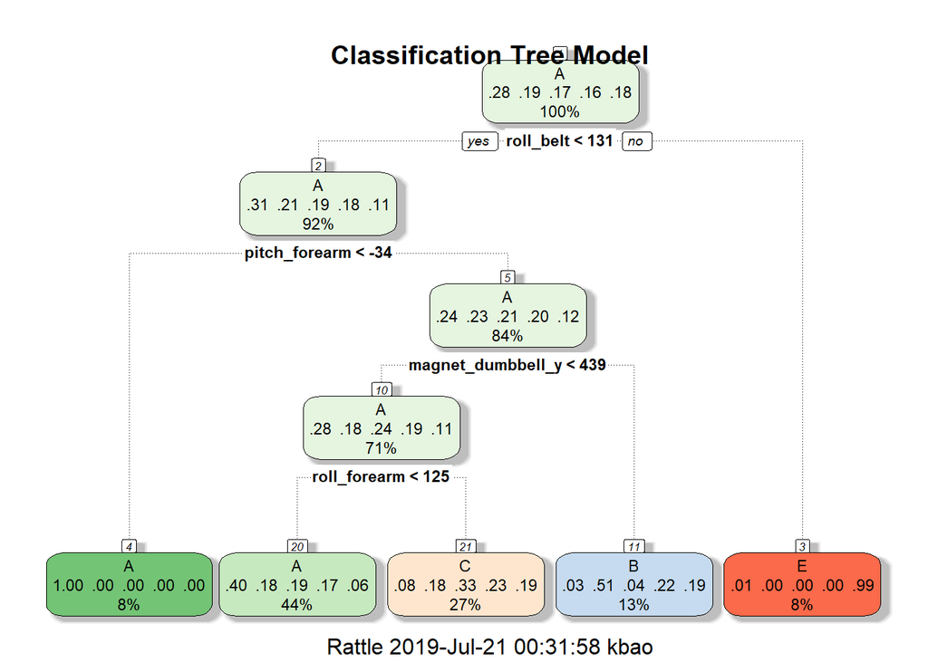

```r
fancyRpartPlot(fit.rpart$finalModel, "Classification Tree Model")
```

```r
pred.rpart <- predict(fit.rpart, newdata = training.test)
confusionMatrix(pred.rpart, training.test$classe)
```

```
## Confusion Matrix and Statistics
##
##           Reference
## Prediction    A    B    C    D    E
##          A 1530  475  468  430  153
##          B   28  385   37  175  147
##          C  110  279  521  359  278
##          D    0    0    0    0    0
##          E    6    0    0    0  504
##
## Overall Statistics
##
##                Accuracy : 0.4996
##                  95% CI : (0.4867, 0.5124)
##     No Information Rate : 0.2845
##     P-Value [Acc > NIR] : < 2.2e-16
##
##                   Kappa : 0.346
##
##  Mcnemar's Test P-Value : NA
##
## Statistics by Class:
##
##                      Class: A Class: B Class: C Class: D Class: E
## Sensitivity            0.9140  0.33802  0.50780   0.0000  0.46580
## Specificity            0.6376  0.91846  0.78885   1.0000  0.99875
## Pos Pred Value         0.5007  0.49870  0.33678      NaN  0.98824
## Neg Pred Value         0.9491  0.85253  0.88359   0.8362  0.89247
## Prevalence             0.2845  0.19354  0.17434   0.1638  0.18386
## Detection Rate         0.2600  0.06542  0.08853   0.0000  0.08564
## Detection Prevalence   0.5193  0.13118  0.26287   0.0000  0.08666
## Balanced Accuracy      0.7758  0.62824  0.64832   0.5000  0.73228
```

The prediction accuracy is 50% and not very useful. We shall explore other models.

## Random Forest

```r
cl <- makePSOCKcluster(2)
registerDoParallel(cl)
fit.rf <- train(classe ~ ., data = training.train, method = "rf")
stopCluster(cl)
```

```r
pred.rf <- predict(fit.rf, newdata = training.test)
confusionMatrix(pred.rf, training.test$classe)
```

```
## Confusion Matrix and Statistics
##
##           Reference
## Prediction    A    B    C    D    E
##          A 1674    9    0    0    0
##          B    0 1128    3    0    2
##          C    0    2 1021   20    1
##          D    0    0    2  943    2
##          E    0    0    0    1 1077
##
## Overall Statistics
##
##                Accuracy : 0.9929
##                  95% CI : (0.9904, 0.9949)
##     No Information Rate : 0.2845
##     P-Value [Acc > NIR] : < 2.2e-16
##
##                   Kappa : 0.991
##
##  Mcnemar's Test P-Value : NA
##
## Statistics by Class:
##
##                      Class: A Class: B Class: C Class: D Class: E
## Sensitivity            1.0000   0.9903   0.9951   0.9782   0.9954
## Specificity            0.9979   0.9989   0.9953   0.9992   0.9998
## Pos Pred Value         0.9947   0.9956   0.9780   0.9958   0.9991
## Neg Pred Value         1.0000   0.9977   0.9990   0.9957   0.9990
## Prevalence             0.2845   0.1935   0.1743   0.1638   0.1839
## Detection Rate         0.2845   0.1917   0.1735   0.1602   0.1830
## Detection Prevalence   0.2860   0.1925   0.1774   0.1609   0.1832
## Balanced Accuracy      0.9989   0.9946   0.9952   0.9887   0.9976
```

This model performed really well with an accuracy of 99%. We shall include this in the final combined model.

## Stochastic Gradient Boosting

```r
cl <- makePSOCKcluster(2)
registerDoParallel(cl)
fit.gbm <- train(classe ~ ., data = training.train, method = "gbm", verbose = FALSE)
stopCluster(cl)
```

```r
pred.gbm <- predict(fit.gbm, newdata = training.test)
confusionMatrix(pred.gbm, training.test$classe)
```

```
## Confusion Matrix and Statistics
##
##           Reference
## Prediction    A    B    C    D    E
##          A 1646   24    0    0    1
##          B   23 1085   35    2   10
##          C    1   27  977   43    6
##          D    3    3   12  905   17
##          E    1    0    2   14 1048
##
## Overall Statistics
##
##                Accuracy : 0.9619
##                  95% CI : (0.9567, 0.9667)
##     No Information Rate : 0.2845
##     P-Value [Acc > NIR] : < 2.2e-16
##
##                   Kappa : 0.9519
##
##  Mcnemar's Test P-Value : 0.0001241
##
## Statistics by Class:
##
##                      Class: A Class: B Class: C Class: D Class: E
## Sensitivity            0.9833   0.9526   0.9522   0.9388   0.9686
## Specificity            0.9941   0.9853   0.9842   0.9929   0.9965
## Pos Pred Value         0.9850   0.9394   0.9269   0.9628   0.9840
## Neg Pred Value         0.9934   0.9886   0.9899   0.9881   0.9929
## Prevalence             0.2845   0.1935   0.1743   0.1638   0.1839
## Detection Rate         0.2797   0.1844   0.1660   0.1538   0.1781
## Detection Prevalence   0.2839   0.1963   0.1791   0.1597   0.1810
## Balanced Accuracy      0.9887   0.9689   0.9682   0.9658   0.9825
```

With an accuracy of 96%, the GBM model performed extremely well.

## Naive Bayes

```r
cl <- makePSOCKcluster(2)
registerDoParallel(cl)
fit.naive_bayes <- train(classe ~ ., data = training.train, method = "naive_bayes")
stopCluster(cl)
```

```r
pred.naive_bayes <- predict(fit.naive_bayes, newdata = training.test)
confusionMatrix(pred.naive_bayes, training.test$classe)
```

```
## Confusion Matrix and Statistics
##
##           Reference
## Prediction    A    B    C    D    E
##          A 1470  228  244  184   61
##          B   23  730   69    4   83
##          C   62  105  663  137   32
##          D  112   56   43  590   39
##          E    7   20    7   49  867
##
## Overall Statistics
##
##                Accuracy : 0.7341
##                  95% CI : (0.7226, 0.7453)
##     No Information Rate : 0.2845
##     P-Value [Acc > NIR] : < 2.2e-16
##
##                   Kappa : 0.6598
##
##  Mcnemar's Test P-Value : < 2.2e-16
##
## Statistics by Class:
##
##                      Class: A Class: B Class: C Class: D Class: E
## Sensitivity            0.8781   0.6409   0.6462   0.6120   0.8013
## Specificity            0.8297   0.9623   0.9308   0.9492   0.9827
## Pos Pred Value         0.6722   0.8031   0.6637   0.7024   0.9126
## Neg Pred Value         0.9448   0.9178   0.9257   0.9259   0.9564
## Prevalence             0.2845   0.1935   0.1743   0.1638   0.1839
## Detection Rate         0.2498   0.1240   0.1127   0.1003   0.1473
## Detection Prevalence   0.3716   0.1545   0.1698   0.1427   0.1614
## Balanced Accuracy      0.8539   0.8016   0.7885   0.7806   0.8920
```

## Linear Discriminant Analysis

```r
cl <- makePSOCKcluster(2)
registerDoParallel(cl)
fit.lda <- train(classe ~ ., data = training.train, method = "lda")
stopCluster(cl)
```

```r
pred.lda <- predict(fit.lda, newdata = training.test)
confusionMatrix(pred.lda, training.test$classe)
```

```
## Confusion Matrix and Statistics
##
##           Reference
## Prediction    A    B    C    D    E
##          A 1375  175   94   51   52
##          B   34  711  117   40  172
##          C  126  147  665  134   90
##          D  131   42  112  695   97
##          E    8   64   38   44  671
##
## Overall Statistics
##
##                Accuracy : 0.6996
##                  95% CI : (0.6877, 0.7113)
##     No Information Rate : 0.2845
##     P-Value [Acc > NIR] : < 2.2e-16
##
##                   Kappa : 0.6197
##
##  Mcnemar's Test P-Value : < 2.2e-16
##
## Statistics by Class:
##
##                      Class: A Class: B Class: C Class: D Class: E
## Sensitivity            0.8214   0.6242   0.6481   0.7210   0.6201
## Specificity            0.9117   0.9235   0.8977   0.9224   0.9679
## Pos Pred Value         0.7871   0.6620   0.5723   0.6453   0.8133
## Neg Pred Value         0.9277   0.9110   0.9236   0.9441   0.9188
## Prevalence             0.2845   0.1935   0.1743   0.1638   0.1839
## Detection Rate         0.2336   0.1208   0.1130   0.1181   0.1140
## Detection Prevalence   0.2969   0.1825   0.1975   0.1830   0.1402
## Balanced Accuracy      0.8665   0.7739   0.7729   0.8217   0.7940
```

Although an accuracy of 70% is decent, it does not meet the cutoff requirement for the final combined model.

## Bagged Classification and Regression Trees

```r
cl <- makePSOCKcluster(2)
registerDoParallel(cl)
fit.treebag <- train(classe ~ ., data = training.train, method = "treebag")
stopCluster(cl)
```

```r
pred.treebag <- predict(fit.treebag, newdata = training.test)
confusionMatrix(pred.treebag, training.test$classe)
```

```
## Confusion Matrix and Statistics
##
##           Reference
## Prediction    A    B    C    D    E
##          A 1658   11    0    0    0
##          B   13 1116    7    6    8
##          C    1    9 1014   23    4
##          D    0    1    3  934    2
##          E    2    2    2    1 1068
##
## Overall Statistics
##
##                Accuracy : 0.9839
##                  95% CI : (0.9803, 0.9869)
##     No Information Rate : 0.2845
##     P-Value [Acc > NIR] : < 2.2e-16
##
##                   Kappa : 0.9796
##
##  Mcnemar's Test P-Value : NA
##
## Statistics by Class:
##
##                      Class: A Class: B Class: C Class: D Class: E
## Sensitivity            0.9904   0.9798   0.9883   0.9689   0.9871
## Specificity            0.9974   0.9928   0.9924   0.9988   0.9985
## Pos Pred Value         0.9934   0.9704   0.9648   0.9936   0.9935
## Neg Pred Value         0.9962   0.9951   0.9975   0.9939   0.9971
## Prevalence             0.2845   0.1935   0.1743   0.1638   0.1839
## Detection Rate         0.2817   0.1896   0.1723   0.1587   0.1815
## Detection Prevalence   0.2836   0.1954   0.1786   0.1597   0.1827
## Balanced Accuracy      0.9939   0.9863   0.9903   0.9838   0.9928
```

## Combined Predictive Model and Predictions

We are ready to predict the actual `testing` data.

We shall combine predictions from the following 3 predictive models:

- `rf` Random Forest
- `gbm` Stochastic Gradient Boosting
- `treebag` Bagged Classification and Regression Trees

Since the `rf` Random Forest model has the highest accuracy, in the case of no majority amongst the 3 models, the Random Forest model’s prediction will be used instead. Else, the majority prediction will be used as the final prediction.

```r
results <- data.frame(rf = predict(fit.rf, newdata = testing),
                      gbm = predict(fit.gbm, newdata = testing),
                      treebag = predict(fit.treebag, newdata = testing))

results <- mutate(results,
                  final = ifelse(rf != gbm & rf != treebag & gbm != treebag, rf,
                                 ifelse(rf == gbm, gbm, treebag)))

results$final <- levels(training$classe)[results$final] # relabel as factors
```

Final predictions are in the `final` column. **(results not displayed in this report to preserve answer integrity)**

```r
results
```